# Анализ выживаемости: ДЗ

## 1. Импорт данных

- **Задача 1.** Загрузите CSV-файл, созданный в `homework-data.qmd`.

```r
data <- read.csv("data.csv")
```

## 2. Анализ функции выживаемости

- **Задача 2.1. Общая кривая выживаемости**
1. Посчитайте оценку Каплана–Майера и постройте кривую выживаемости для всей выборки. Отметьте на кривой цензурированные наблюдения. Отметьте на кривой 95% доверительный интервал.

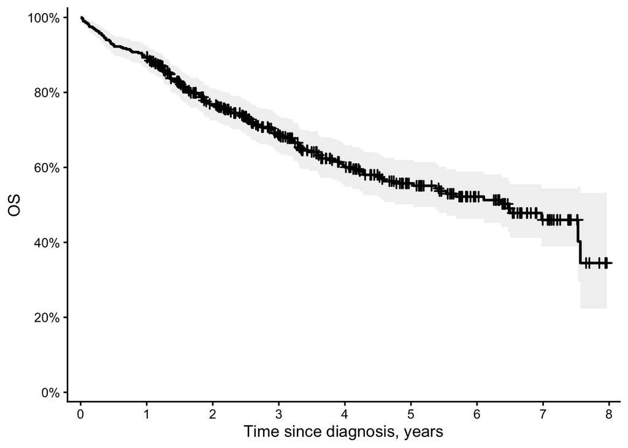

```r
fit <- survfit2(Surv(time, status) ~ 1, data)
ggsurvfit(fit, linewidth = 1) +
  add_censor_mark(stroke = 1) +
  add_confidence_interval(alpha = 0.08) +
  scale_ggsurvfit(
    y_scales = list(breaks = seq(0, 1, 0.2))
  ) +
  theme_classic(base_size = 13) +
  labs(x = "Time since diagnosis, years", y = "OS")
```

2. Оцените медиану **времени наблюдения** двумя способами.
   - Используя метод обратного Каплана–Майера.
   - Вычислите медиану времени наблюдения за выжившими.

```r
fit_cens <- survfit2(Surv(time, abs(status - 1)) ~ 1, data)
median(filter(data, status == 0)$time)
```

```
[1] 3.432107
```

Какой способ корректно оценивает время наблюдения и почему?

3. Оцените медиану **времени до события**. Укажите значения выживаемости с 95% ДИ через год, два года и т. д.

**Дополнительно.** Выберите одну временную точку и подпишите значения в этой точке рядом с кривыми или в легенде.

```r
tbl_survfit(
  fit,
  probs = 0.5,
  statistic = "{estimate}",
  label_header = "median surv, years"
)
```

| **Characteristic** | median surv, years |
| --- | --- |
| Overall | 6.5 |

```r
tbl_survfit(
  fit_cens,
  probs = .5,
  statistic = "{estimate}",
  label_header = "median, years"
)
```

| **Characteristic** | median, years |
| --- | --- |
| Overall | 4.2 |

```r
tbl_survfit(fit, times = seq(1, 8), label_header = "{time}y", label = "OS")
```

| **Characteristic** | 1y | 2y | 3y | 4y | 5y | 6y | 7y | 8y |
| --- | --- | --- | --- | --- | --- | --- | --- | --- |
| OS | 90% (87%, 93%) | 77% (72%, 81%) | 69% (64%, 74%) | 60% (55%, 66%) | 56% (50%, 62%) | 52% (46%, 59%) | 46% (39%, 54%) | 34% (22%, 53%) |

- **Задача 2.2. Сравнение кривых по вмешательству и числу лейкоцитов**
1. Постройте на одном графике кривые Каплана–Майера, сгруппировав пациентов по квартилям или тертилям числа лейкоцитов (WBC). Добавьте 95% доверительные интервалы и таблицу числа пациентов под риском.

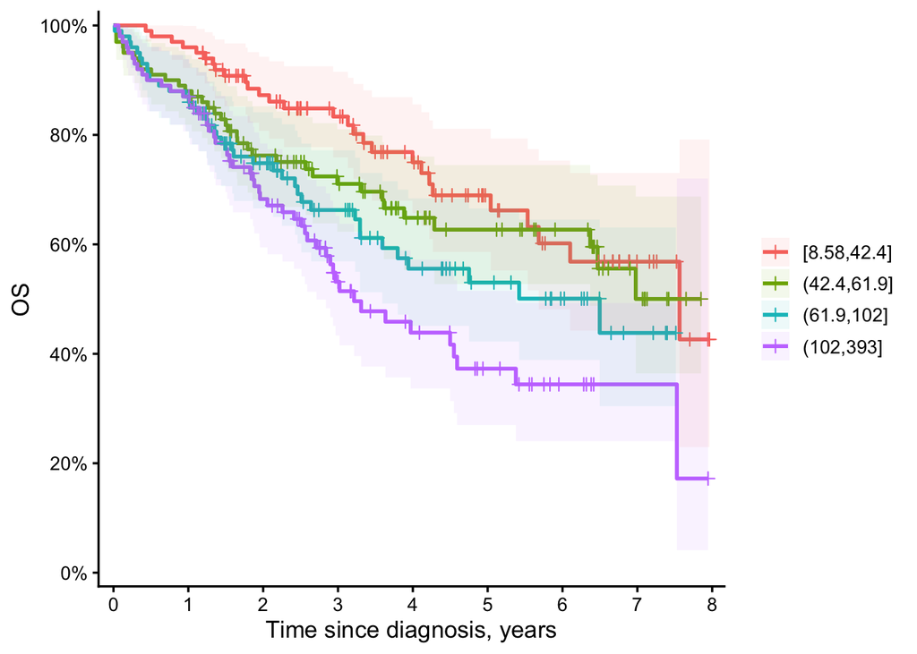

```r
fit_data <- data |>
  mutate(wbc_q4 = cut(wbc, quantile(wbc), include.lowest = T))
fit <- survfit2(Surv(time, status) ~ wbc_q4, fit_data)

ggsurvfit(fit, linewidth = 1) +
  add_censor_mark() +
  add_confidence_interval(alpha = 0.08) +
  scale_ggsurvfit(
    y_scales = list(breaks = seq(0, 1, 0.2))
  ) +
  theme_classic(base_size = 13) +
  labs(x = "Time since diagnosis, years", y = "OS")
```

Прокомментируйте полученный результат.

2. Постройте на одном графике кривые Каплана–Майера для `surgery = 0` и `surgery = 1` по всей выборке. Добавьте 95% доверительные интервалы и таблицу числа пациентов под риском.

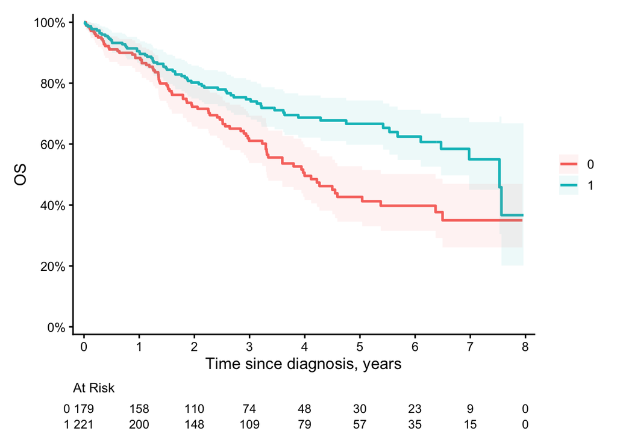

```r
fit <- survfit2(Surv(time, status) ~ surgery, data)
fit_cens <- survfit2(Surv(time, abs(status - 1)) ~ surgery, data)

ggsurvfit(fit, linewidth = 1) +
  add_confidence_interval(alpha = 0.08) +
  add_risktable(risktable_stats = "n.risk") +
  scale_ggsurvfit(
    y_scales = list(breaks = seq(0, 1, 0.2))
  ) +
  theme_classic(base_size = 13) +
  labs(x = "Time since diagnosis, years", y = "OS")
```

3. Соберите таблицу с медианой времени до события в обеих группах. Укажите значения выживаемости с 95% ДИ через год, два года и т. д.

Проинтерпретируйте результаты. Прокомментируйте, как неслучайное назначение вмешательства в зависимости от WBC могло повлиять на полученный выше результат.

4. Разделите пациентов на две подгруппы по числу лейкоцитов: `wbc <= 100` и `wbc > 100`. В каждой подгруппе постройте кривые для `surgery = 0` и `surgery = 1` с 95% доверительными интервалами и таблицей числа пациентов под риском. Покажите результаты на двух графиках, на одном графике с двумя панелями (`facet_wrap()`) или на одном графике с четырьмя кривыми.

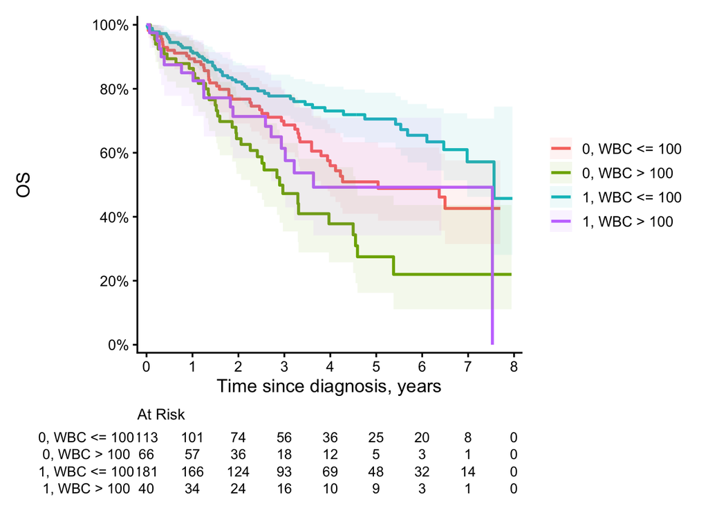

```r
data <- data %>%
  mutate(wbc_bin = case_when(wbc > 100 ~ "WBC > 100", TRUE ~ "WBC <= 100"))
fit <- survfit2(Surv(time, status) ~ surgery + wbc_bin, data)

ggsurvfit(fit, linewidth = 1) +
  add_confidence_interval(alpha = 0.08) +
  add_risktable(risktable_stats = "n.risk") +
  scale_ggsurvfit(
    y_scales = list(breaks = seq(0, 1, 0.2))
  ) +
  theme_classic(base_size = 13) +
  labs(x = "Time since diagnosis, years", y = "OS")
```

- **Задача 2.3. Логранговый критерий**

Проведите два логранговых теста. Сравните `surgery = 0` и `surgery = 1` отдельно среди пациентов с `wbc <= 100` и среди пациентов с `wbc > 100`. Для каждого теста приведите значение статистики и p-значение. Сформулируйте вывод.

```r
fit_data <- data %>% filter(wbc_bin == "WBC > 100")
fit_logrank <- survdiff(Surv(time, status) ~ surgery, fit_data)
glance(fit_logrank) %>%
  gt::gt() %>%
  gt::fmt_number(decimals = 3)
```

| statistic | df | p.value |
| --- | --- | --- |
| 1.845 | 1.000 | 0.174 |

```r
fit_data <- data %>% filter(wbc_bin == "WBC <= 100")
fit_logrank <- survdiff(Surv(time, status) ~ surgery, fit_data)
glance(fit_logrank) %>%
  gt::gt() %>%
  gt::fmt_number(decimals = 3)
```

| statistic | df | p.value |
| --- | --- | --- |
| 5.286 | 1.000 | 0.021 |

## 3. Регрессия Кокса

- **Задача 3.1. Модель только с вмешательством**

Постройте модель Кокса для хирургического вмешательства `surgery`. Представьте коэффициенты регрессии, отношения рисков (HR) с 95% ДИ и p-значения.

```r
fit <- coxph(Surv(time, status) ~ surgery, data)
tidy(fit, conf.int = TRUE, conf.level = 0.95) %>%
  gt::gt() %>%
  gt::fmt_number(decimals = 3)
```

| term | estimate | std.error | statistic | p.value | conf.low | conf.high |
| --- | --- | --- | --- | --- | --- | --- |
| surgery | −0.535 | 0.163 | −3.288 | 0.001 | −0.855 | −0.216 |

- **Задача 3.2. Графическая проверка пропорциональности**

Проверьте допущение о пропорциональности рисков, построив на одном графике кривые на шкале `log(-log(S))`.

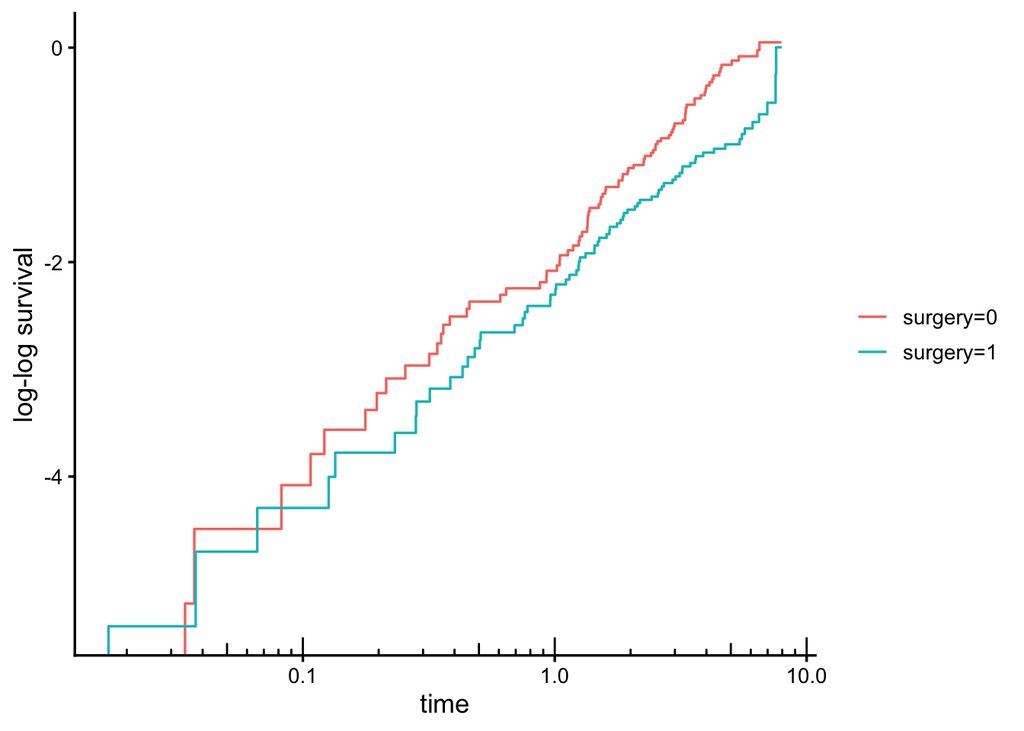

```r
fit <- survfit(Surv(time, status) ~ surgery, data)
ggsurvfit(fit, type = "cloglog") +
  labs(x = "time", y = "log-log survival") +
  scale_x_log10() +
  annotation_logticks(sides = "b") +
  theme_classic(base_size = 13)
```

Есть ли, на ваш взгляд, отклонения от предположения пропорциональности? Если да, то прокомментируйте, где они наблюдаются и на что влияют.

**Задача 3.3. Выбор функциональной формы для числа лейкоцитов**

Исследуйте функциональную форму связи между числом лейкоцитов (`wbc`) и риском после учёта вмешательства. Используйте для этого график остатков мартингейлов. Проверьте линейную зависимость от числа лейкоцитов и логарифма числа лейкоцитов.

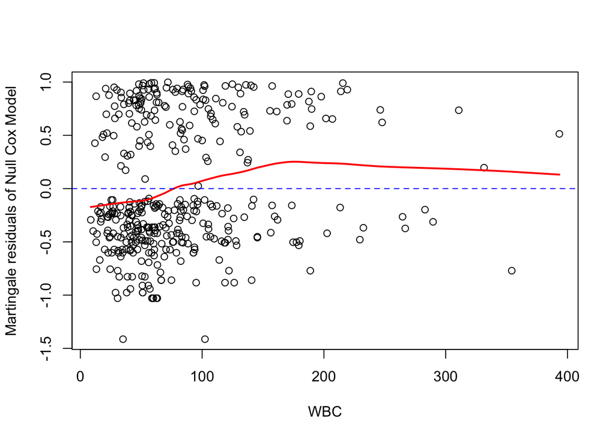

```r
fit <- coxph(Surv(time, status) ~ surgery, data)
mart_res <- residuals(fit, type = "martingale")
plot(
  data$wbc,
  mart_res,
  ylab = "Martingale residuals of Null Cox Model",
  xlab = "WBC"
)
lines(lowess(data$wbc, mart_res), col = "red", lwd = 2)
abline(h = 0, lty = 2, col = "blue")
```

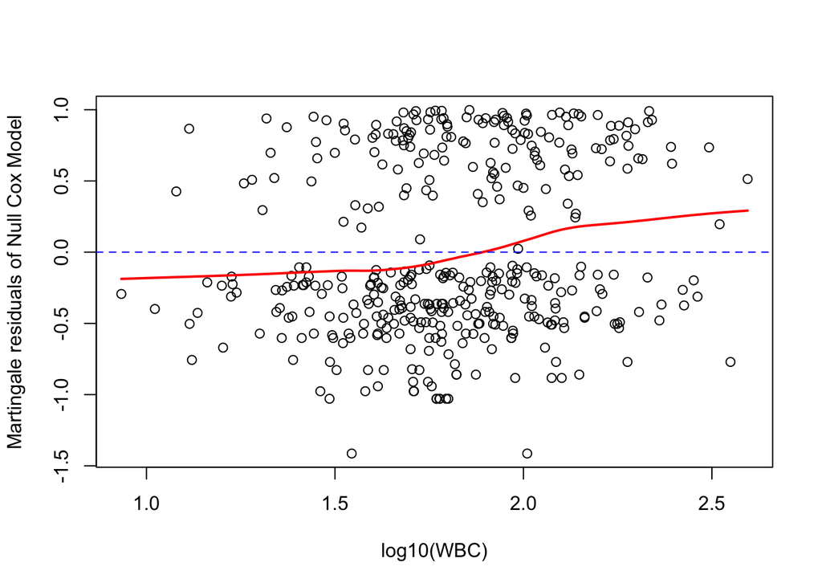

```r
plot(
  log10(data$wbc),
  mart_res,
  ylab = "Martingale residuals of Null Cox Model",
  xlab = "log10(WBC)"
)
lines(lowess(log10(data$wbc), mart_res), col = "red", lwd = 2)
abline(h = 0, lty = 2, col = "blue")
```

Постройте модель Кокса с вмешательством `surgery` и числом лейкоцитов (`wbc`) в форме, выбранной на основе диагностики. Представьте коэффициенты регрессии, отношения рисков (HR) с 95% ДИ и p-значения.

- **Задача 3.4. Проверка пропорциональности для модели с `surgery` и `wbc`**

Возьмите модель из предыдущего пункта и проверьте допущение пропорциональности рисков с помощью остатков Шенфельда.

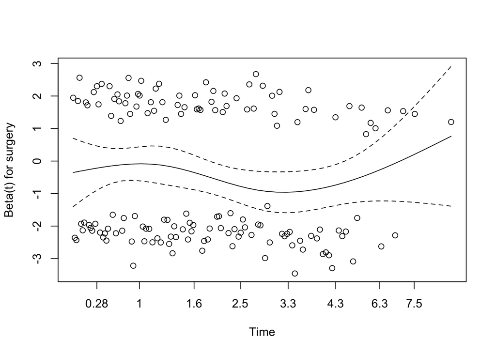

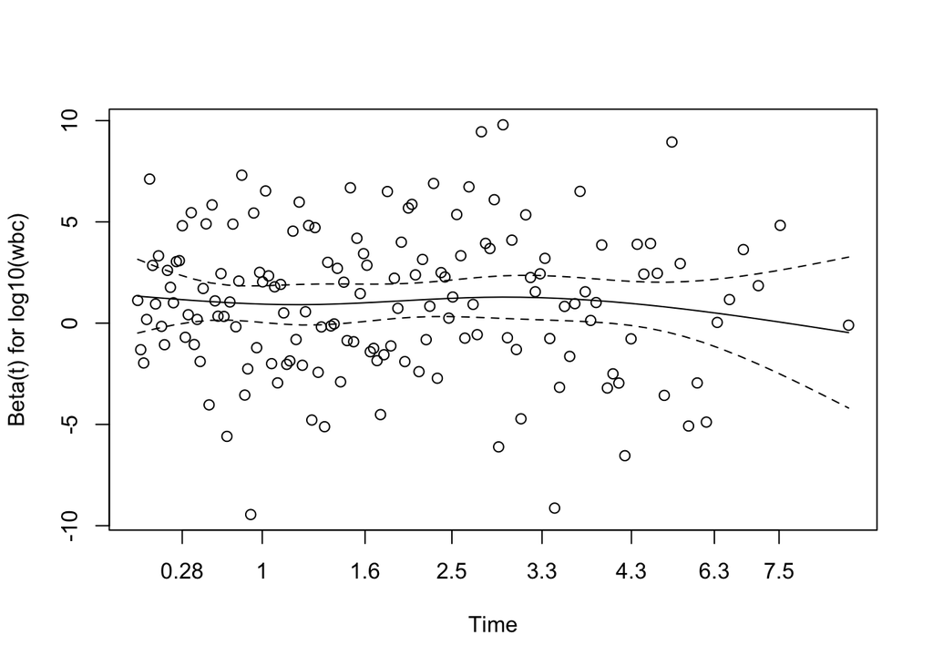

```r
zph_result <- cox.zph(
  coxph(Surv(time, status) ~ surgery + log10(wbc), data),
  transform = "km",
  terms = TRUE,
  singledf = FALSE,
  global = TRUE
)
plot(zph_result)
```

```r
print(zph_result)
```

```
            chisq df    p
surgery    0.8965  1 0.34
log10(wbc) 0.0277  1 0.87
GLOBAL     1.0108  2 0.60
```

Есть ли, на ваш взгляд, отклонения от предположения пропорциональности? Если да, то прокомментируйте, где они наблюдаются и на что влияют.

## 4. Итоговая модель

**Задача 4. Интерпретация модели**

Запишите формулу итоговой модели и полученные оценки. Проинтерпретируйте их: для каждого предиктора объясните, при каком его изменении, в какую сторону и как меняется риск события.

```r
fit <- coxph(Surv(time, status) ~ surgery + log10(wbc), data)
tidy(fit, conf.int = TRUE, conf.level = 0.95, exp = TRUE) %>%
  gt::gt() %>%
  gt::fmt_number(decimals = 3)
```

| term | estimate | std.error | statistic | p.value | conf.low | conf.high |
| --- | --- | --- | --- | --- | --- | --- |
| surgery | 0.650 | 0.166 | −2.598 | 0.009 | 0.470 | 0.900 |
| log10(wbc) | 2.827 | 0.287 | 3.621 | 0.000 | 1.611 | 4.961 |

Вы завершили основную часть домашнего задания! Сохраните файл `.qmd` с кодом, графиками и выводами и соберите HTML-отчет.

**Дополнительное задание.** Вернитесь в файл генерации данных, установите `n <- 400000` и заново запустите симуляцию с теми же параметрами. Посмотрите, как изменились оценки и ширина доверительных интервалов. Сравните оценки, полученные на выборках из 400 и 400 000 наблюдений, с параметрами, заданными при симуляции.